# R Notebook

Manual model development - 7th of January 2021

Calum Sey - CodeClan

You are given a set of data on housing sale prices for the last few years in King County (near Seattle) between May 2014 and May 2015. Have a look at the variable definitions on the Kaggle page

```r
library(tidyverse)
library(broom)
library(ggfortify)
library(GGally)
library(here)
```

```r
kc_data <- read_csv(here("data/kc_house_data.csv"))
```

```r
head(kc_data)
```

| id | date | price | bedrooms | bathrooms | sqft_living | sqft_lot | floors | waterfront | view | condition | grade | sqft_above | sqft_basement | yr_built | yr_renovated | zipcode | lat | long | sqft_living15 | sqft_lot15 |
| --- | --- | --- | --- | --- | --- | --- | --- | --- | --- | --- | --- | --- | --- | --- | --- | --- | --- | --- | --- | --- |
| 7129300520 | 2014-10-13 | 221900 | 3 | 1.00 | 1180 | 5650 | 1 | 0 | 0 | 3 | 7 | 1180 | 0 | 1955 | 0 | 98178 | 47.5112 | -122.257 | 1340 | 5650 |
| 6414100192 | 2014-12-09 | 538000 | 3 | 2.25 | 2570 | 7242 | 2 | 0 | 0 | 3 | 7 | 2170 | 400 | 1951 | 1991 | 98125 | 47.7210 | -122.319 | 1690 | 7639 |
| 5631500400 | 2015-02-25 | 180000 | 2 | 1.00 | 770 | 10000 | 1 | 0 | 0 | 3 | 6 | 770 | 0 | 1933 | 0 | 98028 | 47.7379 | -122.233 | 2720 | 8062 |
| 2487200875 | 2014-12-09 | 604000 | 4 | 3.00 | 1960 | 5000 | 1 | 0 | 0 | 5 | 7 | 1050 | 910 | 1965 | 0 | 98136 | 47.5208 | -122.393 | 1360 | 5000 |
| 1954400510 | 2015-02-18 | 510000 | 3 | 2.00 | 1680 | 8080 | 1 | 0 | 0 | 3 | 8 | 1680 | 0 | 1987 | 0 | 98074 | 47.6168 | -122.045 | 1800 | 7503 |
| 7237550310 | 2014-05-12 | 1225000 | 4 | 4.50 | 5420 | 101930 | 1 | 0 | 0 | 3 | 11 | 3890 | 1530 | 2001 | 0 | 98053 | 47.6561 | -122.005 | 4760 | 101930 |

id - Unique ID for each home sold date - Date of the home sale price - Price of each home sold bedrooms - Number of bedrooms bathrooms - Number of bathrooms, where .5 accounts for a room with a toilet but no shower sqft_living - Square footage of the apartments interior living space sqft_lot - Square footage of the land space floors - Number of floors waterfront - A dummy variable for whether the apartment was overlooking the waterfront or not view - An index from 0 to 4 of how good the view of the property was condition - An index from 1 to 5 on the condition of the apartment, grade - An index from 1 to 13, where 1-3 falls short of building construction and design, 7 has an average level of construction and design, and 11-13 have a high quality level of construction and design. sqft_above - The square footage of the interior housing space that is above ground level sqft_basement - The square footage of the interior housing space that is below ground level yr_built - The year the house was initially built yr_renovated - The year of the house’s last renovation zipcode - What zipcode area the house is in lat - Lattitude long - Longitude sqft_living15 - The square footage of interior housing living space for the nearest 15 neighbors sqft_lot15 - The square footage of the land lots of the nearest 15 neighbors

Task 1 - Tidy up the Data

You might like to think about removing some or all of date, id, sqft_living15, sqft_lot15 and zipcode (lat and long provide a better measure of location in any event).

Have a think about how to treat waterfront. Should we convert its type?

We converted yr_renovated into a renovated logical variable, indicating whether the property had ever been renovated. You may wish to do the same.

Have a think about how to treat condition and grade? Are they interval or categorical ordinal data types?

```r
kc_data <- kc_data %>%
  select(-c(id, date, sqft_living15, sqft_lot15, zipcode)) %>%
  mutate(waterfront = as.logical(waterfront)) %>%
  mutate(renovated = as.logical(yr_renovated)) %>%
  select(-yr_renovated) %>%
  mutate(grade = factor(grade, levels = c(seq(1,15,1))))
```

Task 2

Check for aliased variables using the alias() function (this takes in a formula object and a data set). [Hint - formula price ~ . says ‘price varying with all predictors’, this is a suitable input to alias()]. Remove variables that lead to an alias. Check the ‘Elements of multiple regression’ lesson for a dropdown containing further information on finding aliased variables in a dataset.

```r
alias(lm(formula = price ~ ., data = kc_data))
```

```
Model :
price ~ bedrooms + bathrooms + sqft_living + sqft_lot + floors +
    waterfront + view + condition + grade + sqft_above + sqft_basement +
    yr_built + lat + long + renovated

Complete :
              (Intercept) bedrooms bathrooms sqft_living sqft_lot floors waterfrontTRUE view
sqft_basement  0           0        0         1           0        0      0              0
              condition grade3 grade4 grade5 grade6 grade7 grade8 grade9 grade10 grade11
sqft_basement  0         0      0      0      0      0      0      0      0       0
              grade12 grade13 sqft_above yr_built lat long renovatedTRUE
sqft_basement  0       0      -1          0        0   0    0
```

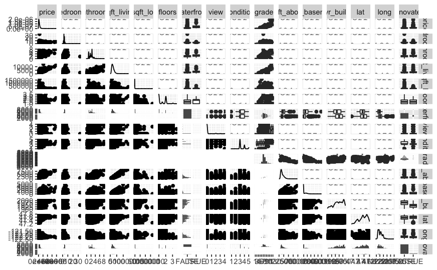

```r
ggpairs(kc_data)
```

```r
mod1a <- lm(price ~ bedrooms, data = kc_data)
```

[output not shown]

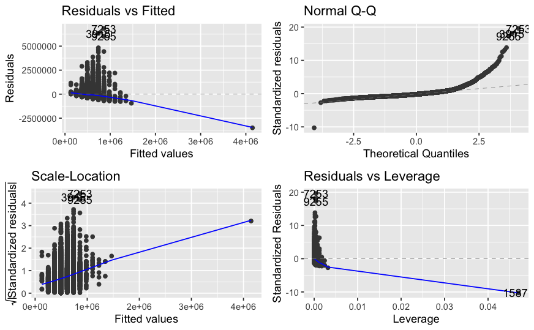

```r
autoplot(mod1a)
```

```r
summary(mod1a)
```

```
Call:
lm(formula = price ~ bedrooms, data = kc_data)

Residuals:
     Min       1Q   Median       3Q      Max
-3506435  -203235   -66667   105049  6839901

Coefficients:
            Estimate Std. Error t value Pr(>|t|)
(Intercept)   129802       8932   14.53   <2e-16 ***
bedrooms      121716       2554   47.65   <2e-16 ***
---
Signif. codes:  0 ‘***’ 0.001 ‘**’ 0.01 ‘*’ 0.05 ‘.’ 0.1 ‘ ’ 1

Residual standard error: 349200 on 21611 degrees of freedom
Multiple R-squared:  0.09508,   Adjusted R-squared:  0.09504
F-statistic:  2271 on 1 and 21611 DF,  p-value: < 2.2e-16
```

```r
mod1b <- lm(price ~ grade, data = kc_data)
```

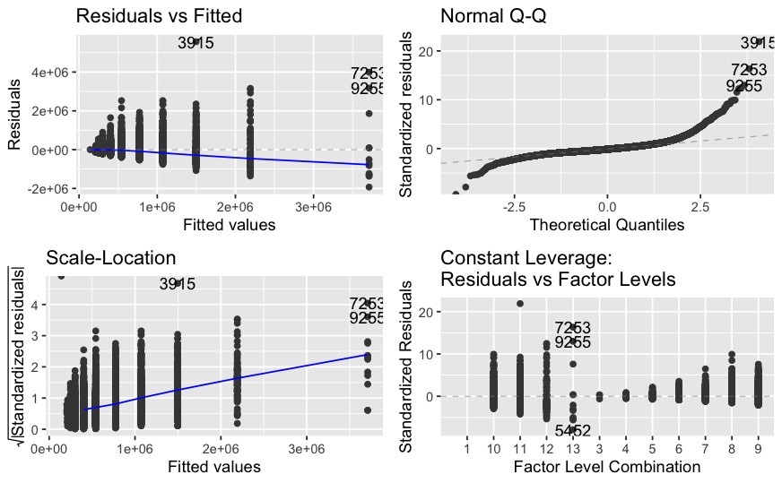

```r
autoplot(mod1b)
```

```r
summary(mod1b)
```

```
Call:
lm(formula = price ~ grade, data = kc_data)

Residuals:
     Min       1Q   Median       3Q      Max
-1929615  -135853   -35090    89080  5565658

Coefficients:
            Estimate Std. Error t value Pr(>|t|)
(Intercept)   142000     254499   0.558 0.576878
grade3         63667     293870   0.217 0.828484
grade4         72381     258849   0.280 0.779767
grade5        106524     255024   0.418 0.676169
grade6        159920     254561   0.628 0.529868
grade7        260590     254513   1.024 0.305904
grade8        400853     254520   1.575 0.115285
grade9        631513     254547   2.481 0.013112 *
grade10       929771     254611   3.652 0.000261 ***
grade11      1354842     254817   5.317 1.07e-07 ***
grade12      2049222     255909   8.008 1.23e-15 ***
grade13      3567615     264106  13.508  < 2e-16 ***
---
Signif. codes:  0 ‘***’ 0.001 ‘**’ 0.01 ‘*’ 0.05 ‘.’ 0.1 ‘ ’ 1

Residual standard error: 254500 on 21601 degrees of freedom
Multiple R-squared:  0.5197,    Adjusted R-squared:  0.5195
F-statistic:  2125 on 11 and 21601 DF,  p-value: < 2.2e-16
```

```r
mod2a <- lm(price ~ bedrooms + sqft_living, data = kc_data)
```

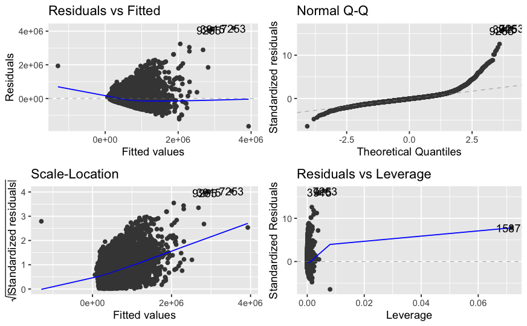

```r
autoplot(mod2a)
```

```r
summary(mod2a)
```

```
Call:
lm(formula = price ~ bedrooms + sqft_living, data = kc_data)

Residuals:
     Min       1Q   Median       3Q      Max
-1650867  -143866   -23143   102344  4179850

Coefficients:
              Estimate Std. Error t value Pr(>|t|)
(Intercept)  79469.359   6604.764   12.03   <2e-16 ***
bedrooms    -57066.759   2308.223  -24.72   <2e-16 ***
sqft_living    313.949      2.337  134.31   <2e-16 ***
---
Signif. codes:  0 ‘***’ 0.001 ‘**’ 0.01 ‘*’ 0.05 ‘.’ 0.1 ‘ ’ 1

Residual standard error: 257800 on 21610 degrees of freedom
Multiple R-squared:  0.5068,    Adjusted R-squared:  0.5068
F-statistic: 1.11e+04 on 2 and 21610 DF,  p-value: < 2.2e-16
```

```r
mod2b <- lm(price ~ bedrooms + bathrooms, data = kc_data)
```

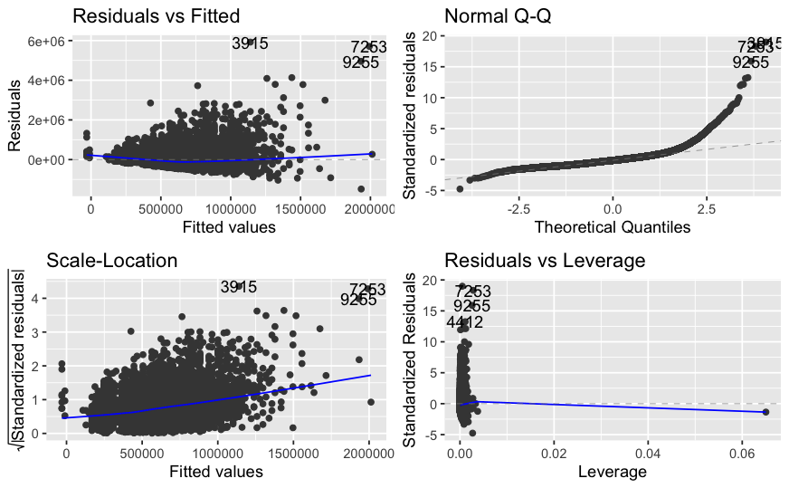

```r
autoplot(mod2b)
```

```r
summary(mod2b)
```

```
Call:
lm(formula = price ~ bedrooms + bathrooms, data = kc_data)

Residuals:
     Min       1Q   Median       3Q      Max
-1483956  -184367   -42552   111612  5922439

Coefficients:
            Estimate Std. Error t value Pr(>|t|)
(Intercept)   -30643       8270  -3.705 0.000212 ***
bedrooms       20138       2664   7.559 4.21e-14 ***
bathrooms     237781       3217  73.912  < 2e-16 ***
---
Signif. codes:  0 ‘***’ 0.001 ‘**’ 0.01 ‘*’ 0.05 ‘.’ 0.1 ‘ ’ 1

Residual standard error: 312000 on 21610 degrees of freedom
Multiple R-squared:  0.2777,    Adjusted R-squared:  0.2776
F-statistic:  4154 on 2 and 21610 DF,  p-value: < 2.2e-16
```

```r
anova(mod1a, mod2a)
```

```
Analysis of Variance Table

Model 1: price ~ bedrooms
Model 2: price ~ bedrooms + sqft_living
  Res.Df        RSS Df  Sum of Sq     F    Pr(>F)
1  21611 2.6360e+15
2  21610 1.4366e+15  1 1.1993e+15 18040 < 2.2e-16 ***
---
Signif. codes:  0 ‘***’ 0.001 ‘**’ 0.01 ‘*’ 0.05 ‘.’ 0.1 ‘ ’ 1
```